# Homework 3

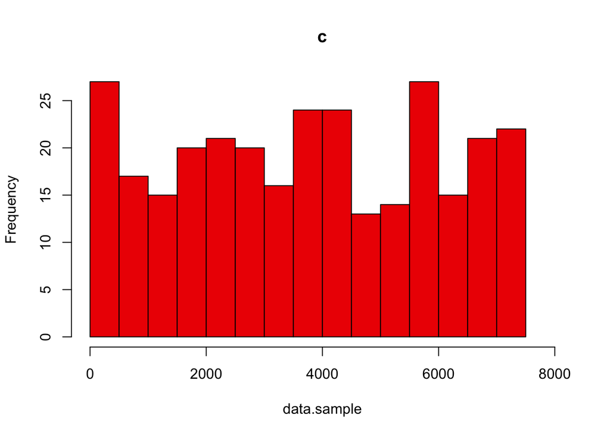

```r
data.sample <- sample.int(N, size=n, replace=FALSE)
cHistogram = hist(data.sample, xlim=c(0,8000), breaks=16, col='red2', main="c")
```

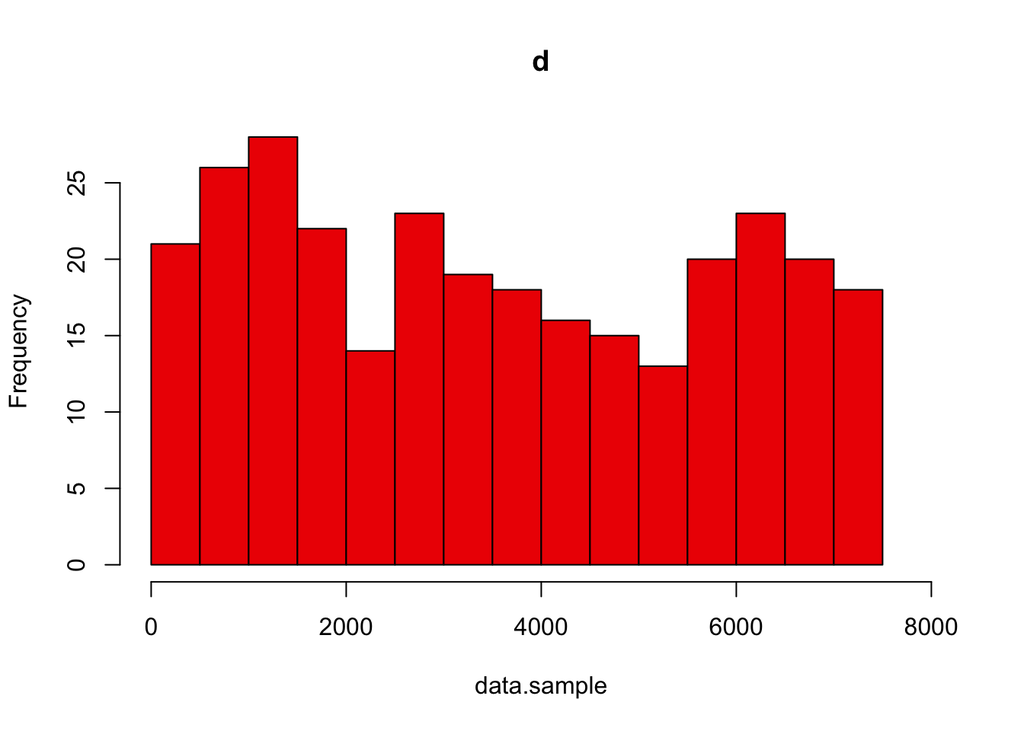

```r
data.sample <- sample.int(N, size=n, replace=FALSE)
dHistogram = hist(data.sample, xlim=c(0,8000), breaks=16,col='red2', main="d")
```

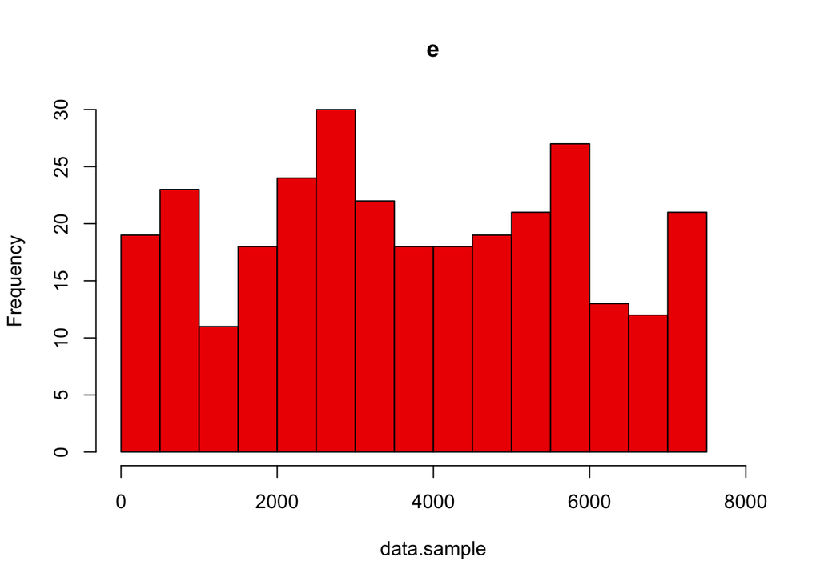

```r
data.sample <- sample.int(N, size=n, replace=FALSE)
eHistogram = hist(data.sample, xlim=c(0,8000), breaks=16, col='red2', main="e")
```

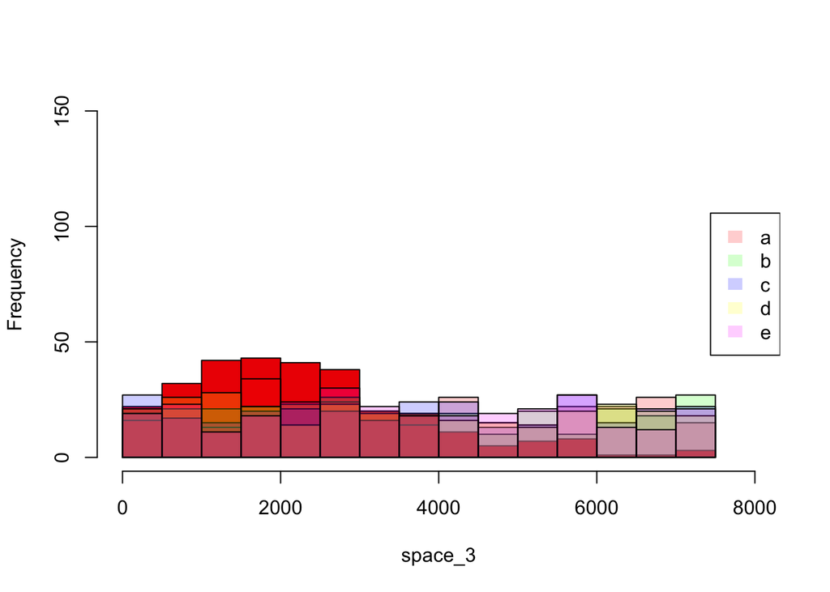

```r
aHistColor = rgb(1,0,0,0.2)
bHistColor = rgb(0,1,0,0.2)
cHistColor = rgb(0,0,1,0.2)
dHistColor = rgb(1,1,0,0.2)
eHistColor = rgb(1,0,1,0.2)

plot(hist_3, col='red2', ylim=c(0,150), xlim=c(0,8000), main=NA)
plot(aHistogram, col=aHistColor, ylim=c(0,150), xlim=c(0,8000), add=T)
plot(bHistogram, col=bHistColor, ylim=c(0,150), xlim=c(0,8000), add=T)
plot(cHistogram, col=cHistColor, ylim=c(0,150), xlim=c(0,8000), add=T)
plot(dHistogram, col=dHistColor, ylim=c(0,150), xlim=c(0,8000), add=T)
plot(eHistogram, col=eHistColor, ylim=c(0,150), xlim=c(0,8000), add=T)


legend('right', c('a', 'b', 'c', 'd', 'e'), fill=c(aHistColor, bHistColor, cHistColor, dHistColor, eHistColor), border=NA)
```

### 2c)

Compare 2a and 2b

### 2d)

Identify the theoretical distributions of the spacings from the random uniform scatter (we should identify 3 theoretical distributions, each for a different spacing)

### 2e)

Overlay the identified theoretical distributions as cdf on the plots in 2). (5x3 cdf?)

*If you are plotting histograms, a density is more appropriate. If you are plotting cdfs, a cdf is more appropriate. Yes you are intended to overlay your densities/cdfs in their appropriate plots but again, try to be as concise as possible when visualizing.*

## 3.

**Counts:** Here the goal is to use graphical and formal statistical methods to examine the counts of palindromes in regions of the DNA. Be sure to do this for a few different (but reasonable) interval lengths. The graphical displays should compare the distribution of counts to random uniform scatter (this will be analogous to the locations and spacings sections). Using results from lecture, you can organize a formal statistical test to further examine your distributions of counts.

```r
regionsplit <- function(n.region, gene, site){
  count.int <- table(cut(site, breaks = seq(1, length(gene), length.out=n.region+1), include.lowest=TRUE))
  count.vector <- as.vector(count.int)
  count.tab <- table(factor(count.vector,levels=0:max(count.vector)))
  return (count.tab)
}
```

```r
n.region <- 50
N <- max(data, na.rm=TRUE)
gene <- seq(177, N)
O1.tab=regionsplit(n.region, gene, data$location)
O2.tab=regionsplit(n.region, gene, data_sample)
O3.tab=regionsplit(n.region, gene, data_unif)
O1.tab
```

```
##
##  0  1  2  3  4  5  6  7  8  9 10 11 12 13 14 15 16
##  1  1  1  6  6  7  6 13  3  3  1  1  0  0  0  0  1
```

```r
O2.tab
```

```
##
##  0  1  2  3  4  5  6  7  8  9 10 11 12 13 14 15 16 17 18 19
##  3  1  6  4  4  5  6 10  1  3  3  2  0  0  0  1  0  0  0  1
```

```r
O3.tab
```

```
##
##  0  1  2  3  4  5  6  7  8  9 10 11 12 13 14 15 16 17 18 19 20 21 22 23 24 25
##  0  0  0  0  0  0  0  0  0  0  1  0  0  1  2  5  1  2  7  4  5  5  6  3  3  1
## 26 27 28 29 30 31 32 33 34
##  0  0  3  0  0  0  0  0  1
```

```r
trunc=9
lvls=factor(c(0:(trunc-1),paste(">=",trunc,sep="")),levels=c(0:(trunc-1),paste(">=",trunc,sep="")))
O1=as.vector(O1.tab)
O2=as.vector(O2.tab)
O3=as.vector(O3.tab)
O1.trunc=c(O1[1:trunc],sum(O1[-(1:trunc)]))
O2.trunc=c(O2[1:trunc],sum(O2[-(1:trunc)]))
O3.trunc=c(O3[1:trunc],sum(O3[-(1:trunc)]))
lambda=n/n.region
p=c(dpois(0:(trunc-1),lambda),1-sum(dpois(0:(trunc-1),lambda)))
E=p*n.region
tab1=data.frame(levels=lvls,Observed=O1.trunc,Expected=E)
tab2=data.frame(levels=lvls,Observed=O2.trunc,Expected=E)
tab3=data.frame(levels=lvls,Observed=O3.trunc,Expected=E)
tab1
```

```
##    levels Observed  Expected
## 1       0        1 0.1342600
## 2       1        1 0.7948193
## 3       2        1 2.3526650
## 4       3        6 4.6425922
## 5       4        6 6.8710365
## 6       5        7 8.1353072
## 7       6        6 8.0268365
## 8       7       13 6.7884103
## 9       8        3 5.0234236
## 10    >=9        6 7.2306494
```

```r
tab2
```

```
##    levels Observed  Expected
## 1       0        3 0.1342600
## 2       1        1 0.7948193
## 3       2        6 2.3526650
## 4       3        4 4.6425922
## 5       4        4 6.8710365
## 6       5        5 8.1353072
## 7       6        6 8.0268365
## 8       7       10 6.7884103
## 9       8        1 5.0234236
## 10    >=9       10 7.2306494
```

```r
tab3
```

```
##    levels Observed  Expected
## 1       0        0 0.1342600
## 2       1        0 0.7948193
## 3       2        0 2.3526650
## 4       3        0 4.6425922
## 5       4        0 6.8710365
## 6       5        0 8.1353072
## 7       6        0 8.0268365
## 8       7        0 6.7884103
## 9       8        0 5.0234236
## 10    >=9       50 7.2306494
```

```r
chisq.test(O1.trunc,p=p,simulate.p.value=TRUE)
```

```
##
##  Chi-squared test for given probabilities with simulated p-value (based
##  on 2000 replicates)
##
## data:  O1.trunc
## X-squared = 14.299, df = NA, p-value = 0.1174
```

```r
chisq.test(O2.trunc,p=p,simulate.p.value=TRUE)
```

```
##
##  Chi-squared test for given probabilities with simulated p-value (based
##  on 2000 replicates)
##
## data:  O2.trunc
## X-squared = 75.687, df = NA, p-value = 0.0009995
```

```r
chisq.test(O3.trunc,p=p,simulate.p.value=TRUE)
```

```
##
##  Chi-squared test for given probabilities with simulated p-value (based
##  on 2000 replicates)
##
## data:  O3.trunc
## X-squared = 295.75, df = NA, p-value = 0.0004998
```

## 4.

**Biggest Cluster:** Here the goal is to use randomization or theory to examine the largest cluster of palindromes in a sub-interval. Again, you’re expected to try a few different interval sizes. With respect to the randomization, focus on the probability of obtaining, in any subinterval, a count as large or larger than the count you observe in your sample. There is also a theoretical approach to obtaining such a probability. You are free to implement either method.